# Coursework_MAP501_2023

# Question 2 (Multiple Regression for Count Data)

1. Create a dataset ‘df_FieldingData’ from ‘Fielding’ by
2. selecting data of the two years 1990 and 2015 (note that it is not all the years 1990 to 2015).
2. selecting playerID, year and position. Then create a dataset ‘df_BattingData’ from the dataset ‘Batting’ by:
3. selecting data of the two years 1990 and 2015,
4. adding height, weight, birthYear of players from ‘People’.
5. adding position played from ‘df_FieldingData’
6. creating a new variable ‘age’ equal to each player’s age in the relevant year,
7. dropping incomplete cases from the dataset and dropping unused levels of any categorical variable.
8. remove duplication in players (i.e., each player’s data is in a single row). Use ‘df_BattingData’ for the rest of question 2. Note: use one code chunk for a.

```r
# Create df_FieldingData from 'Fielding' dataset for years 1990 and 2015
df_FieldingData <- subset(Fielding, yearID %in% c(1990, 2015), select = c(playerID, yearID, POS))

# Create df_BattingData from 'Batting' dataset for years 1990 and 2015
df_BattingData <- subset(Batting, yearID %in% c(1990, 2015))

# Add height, weight, birthYear from 'People' dataset
df_BattingData <- merge(df_BattingData, People[, c("playerID", "height", "weight", "birthYear")], by = "playerID", all.x = TRUE)

# Add position played from df_FieldingData
df_BattingData <- merge(df_BattingData, df_FieldingData, by = c("playerID", "yearID"), all.x = TRUE)

# Create 'age' variable equal to each player’s age in the relevant year
df_BattingData$age <- df_BattingData$yearID - df_BattingData$birthYear

# Drop incomplete cases
df_BattingData <- na.omit(df_BattingData)

# Drop unused levels of categorical variables
df_BattingData <- droplevels(df_BattingData)

# Remove duplication in players
library(dplyr)
df_BattingData <- df_BattingData %>%
  distinct(playerID, .keep_all = TRUE)
```

2. Create a histogram of the number of runs scored for players. Next create a histogram of the number of runs for all players who have had a hit. Why it is more reasonable to create a Poisson data for the second set than the first.

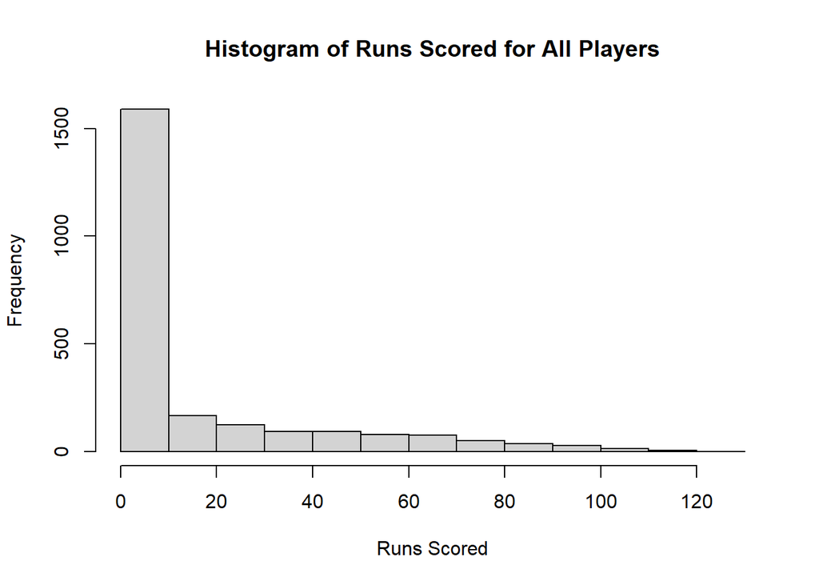

```r
# Histogram of Runs Scored for All Players
hist(df_BattingData$R, xlab = "Runs Scored", main = "Histogram of Runs Scored for All Players")
```

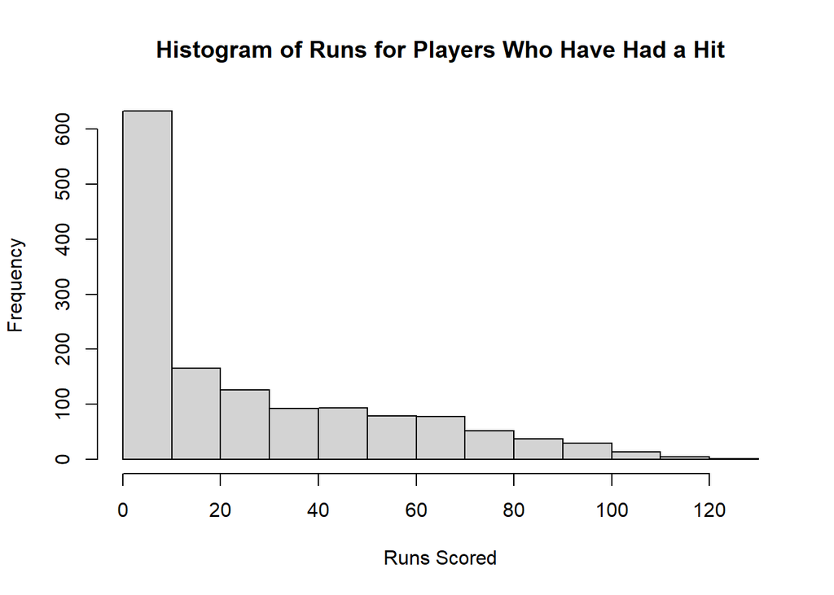

```r
# Filter players who have had at least one hit
hits_players <- subset(df_BattingData, H > 0)

# Histogram of Runs for Players Who Have Had a Hit
hist(hits_players$R, xlab = "Runs Scored", main = "Histogram of Runs for Players Who Have Had a Hit")
```

Building a histogram based on hits may be more appropriate for a Poisson distribution since the supposition that hits result in runs may fit the features of a Poisson process, in which hits happen independently at a steady pace and affect the number of runs scored. However, taking into account every player could result in the introduction of non-Poisson factors (such as walks, errors, etc.), which could reduce the overall distribution’s suitability for a Poisson model.

3. Excluding players who have had no hit, construct a Poisson model of the number of runs as a function of the number of hits, the year as a factor, position played and player height and age in the relevant year. Interpret the results and write the form of the fitted model (coefficients should be rounded to 2 significant figures)

```r
# Filter data for players who have had at least one hit
hits_data <- subset(df_BattingData, H > 0)

# Fitting the Poisson regression model
poisson_model <- glm(R ~ H + factor(yearID) + POS + height + age,
                     data = hits_players, family = "poisson")

# Summary of the Poisson model
summary(poisson_model)
```

```
##
## Call:
## glm(formula = R ~ H + factor(yearID) + POS + height + age, family = "poisson",
##     data = hits_players)
##
## Coefficients:
##                      Estimate Std. Error z value Pr(>|z|)
## (Intercept)         1.733e+00  2.002e-01   8.658  < 2e-16 ***
## H                   1.414e-02  9.676e-05 146.170  < 2e-16 ***
## factor(yearID)2015  2.583e-03  1.053e-02   0.245 0.806219
## POS2B              -1.430e-02  1.986e-02  -0.720 0.471488
## POS3B              -5.770e-02  2.004e-02  -2.879 0.003992 **
## POSC               -1.461e-01  2.315e-02  -6.313 2.74e-10 ***
## POSOF               7.714e-02  1.504e-02   5.128 2.94e-07 ***
## POSP               -1.519e+00  4.349e-02 -34.933  < 2e-16 ***
## POSSS              -1.769e-02  2.114e-02  -0.837 0.402738
## height              4.369e-03  2.623e-03   1.666 0.095748 .
## age                 5.295e-03  1.389e-03   3.813 0.000137 ***
## ---
## Signif. codes:  0 '***' 0.001 '**' 0.01 '*' 0.05 '.' 0.1 ' ' 1
##
## (Dispersion parameter for poisson family taken to be 1)
##
##     Null deviance: 42545.7  on 1406  degrees of freedom
## Residual deviance:  6017.7  on 1396  degrees of freedom
## AIC: 11771
##
## Number of Fisher Scoring iterations: 5
```